# Cardio Good Fitness (Project 1)

## Submitted by Sumant Sarkar (Jan'22 Cohort)

The goal of this project is to explore the cardio good fitness dataset and (a) come up with a customer profile (characteristics of a customer) of the different products (b) perform univariate and multivariate analyses (c) generate a set of insights and recommendations that will help the company in targeting new customers

The dataset has the following attributes:

1. Product - The model no. of the treadmill
2. Age - Age of the customer in no of years
3. Gender - Gender of the customer
4. Education - Education of the customer in no. of years
5. Marital Status - Marital status of the customer
6. Usage - Avg. # times the customer wants to use the treadmill every week
7. Fitness - Self rated fitness score of the customer (5 - very fit, 1 - very unfit)
8. Income - Income of the customer
9. Miles- Miles that a customer expects to run

```python
# import all the python packages that will be needed. If any package is missing, install it first using this command:
# !pip install <package name>

import pandas as pd
import numpy as np
import seaborn as sns
import matplotlib.pyplot as plt  # seaborn is based on matplotlib
import matplotlib.ticker as tkr

sns.set(color_codes=True) # adds a nice background to the graphs
%matplotlib inline
from pandas_profiling import ProfileReport
```

```python
# Read in the data file. Get the row/column counts. See a few rows to make sure the reading was done correctly
cdata = pd.read_csv('CardioGoodFitness.csv')
print(cdata.shape)
print('')
print(cdata.dtypes)
print('')
cdata.head()
```

```
(180, 9)

Product          object
Age               int64
Gender           object
Education         int64
MaritalStatus    object
Usage             int64
Fitness           int64
Income            int64
Miles             int64
dtype: object
```

|  | Product | Age | Gender | Education | MaritalStatus | Usage | Fitness | Income | Miles |
| --- | --- | --- | --- | --- | --- | --- | --- | --- | --- |
| 0 | TM195 | 18 | Male | 14 | Single | 3 | 4 | 29562 | 112 |
| 1 | TM195 | 19 | Male | 15 | Single | 2 | 3 | 31836 | 75 |
| 2 | TM195 | 19 | Female | 14 | Partnered | 4 | 3 | 30699 | 66 |
| 3 | TM195 | 19 | Male | 12 | Single | 3 | 3 | 32973 | 85 |
| 4 | TM195 | 20 | Male | 13 | Partnered | 4 | 2 | 35247 | 47 |

```python
# Data types above are as expected. So far it looks good.
# Let's see some basic stats (mean, min, max, median etc.) of the columns. For non-numeric columns, not all metrics make sense. These will show up as NaN.
cdata.describe(include='all')
```

|  | Product | Age | Gender | Education | MaritalStatus | Usage | Fitness | Income | Miles |
| --- | --- | --- | --- | --- | --- | --- | --- | --- | --- |
| count | 180 | 180.000000 | 180 | 180.000000 | 180 | 180.000000 | 180.000000 | 180.000000 | 180.000000 |
| unique | 3 | NaN | 2 | NaN | 2 | NaN | NaN | NaN | NaN |
| top | TM195 | NaN | Male | NaN | Partnered | NaN | NaN | NaN | NaN |
| freq | 80 | NaN | 104 | NaN | 107 | NaN | NaN | NaN | NaN |
| mean | NaN | 28.788889 | NaN | 15.572222 | NaN | 3.455556 | 3.311111 | 53719.577778 | 103.194444 |
| std | NaN | 6.943498 | NaN | 1.617055 | NaN | 1.084797 | 0.958869 | 16506.684226 | 51.863605 |
| min | NaN | 18.000000 | NaN | 12.000000 | NaN | 2.000000 | 1.000000 | 29562.000000 | 21.000000 |
| 25% | NaN | 24.000000 | NaN | 14.000000 | NaN | 3.000000 | 3.000000 | 44058.750000 | 66.000000 |
| 50% | NaN | 26.000000 | NaN | 16.000000 | NaN | 3.000000 | 3.000000 | 50596.500000 | 94.000000 |
| 75% | NaN | 33.000000 | NaN | 16.000000 | NaN | 4.000000 | 4.000000 | 58668.000000 | 114.750000 |
| max | NaN | 50.000000 | NaN | 21.000000 | NaN | 7.000000 | 5.000000 | 104581.000000 | 360.000000 |

```python
# Let's check if there are any blanks
cdata.isnull().sum()
```

```
Product          0
Age              0
Gender           0
Education        0
MaritalStatus    0
Usage            0
Fitness          0
Income           0
Miles            0
dtype: int64
```

```python
# There are no blanks. That's good.
# Let's use the pandas profile package to create a basic report on the dataset
# The profile report is in a cell with its own scrolling. So scroll within the cell to see the entire report.
profile = ProfileReport(cdata);
profile
```

[interactive chart not shown]

```python
# Save the report file as an HTML for future viewing
profile.to_file("cdata_profile.html")
```

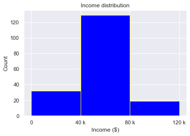

```python
# Let's re-plot the income distribution, but with just three bins as opposed to the large number of bins we got in the pandas report.
# The bin boundaries are decided based on the min/max we saw earlier.

fig, ax = plt.subplots()
plt.hist(cdata["Income"], bins=[0,40000,80000,120000],edgecolor="yellow", color="blue")
ax.set_title('Income distribution')
plt.xlabel('Income ($)')
plt.ylabel('Count')
formatter0 = tkr.EngFormatter()
ax.xaxis.set_major_formatter(formatter0)
ax.set_xticks([0,40000,80000,120000])
plt.show()
```

1. Based on the pandas profile report above, we see that there are no missing values in any features.
2. TM195 sells twice as TM798 does.
3. The age distribution is right skewed. Most of the customers are around 25 years old. Mean age is 28 and median is 26 years.
4. There are significantly more male customers than female.
5. As to education level, most of the customers are college graduate (16 years) and some-college (~14 years) category.
6. A majority of the customers are partnered.
7. Usage has a right skewed distribution. So do income and miles.
8. The largest number of customers is the mid-income level customers. We will box plots later to get more insight into this.

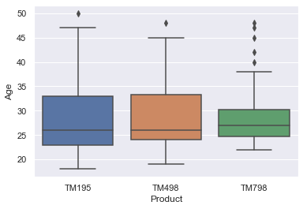

```python
# Univariate charts were created in the above report. Let's create a few more plots that have additional dimensions.
# One of the key goals of this project is to identify the customer profile of different products.
# So it makes sense to use the Product as a dimension in the plots. That's what we will do, to begin with.
# This box plot below shows the spread of Age for each of the Product in the dataset
sns.boxplot(data = cdata, x ='Product', y ='Age');
```

We notice that the median age across the products is almost identical. However, for TM798, the spread is much more narrow. Barring the outliers, it appears that this product is preferred by a narrow age band, whereas the other two products have an appeal for a larger age band. This should be looked into in a greater detail.

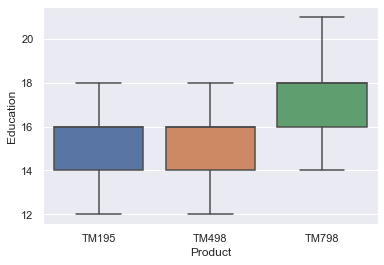

```python
# Let's slice the same data by Education level now.
sns.boxplot(data = cdata, x ='Product', y ='Education');
```

Clearly, the TM798 product is preferred by those who are more educated. This information could be utilized for identifying a customer segment and marketing to this segment with targetted promotional campaigns.

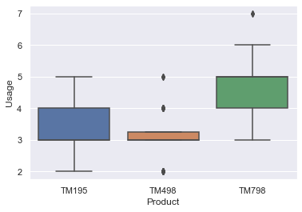

```python
# Let's see if there is a difference in usage across the products.
sns.boxplot(data = cdata, x ='Product', y ='Usage');
```

Clearly, the TM798 product is also used more than the others. We cannot assume a causal relationship though. There could be other factors that explain this. All we have at the moment is a correlation.

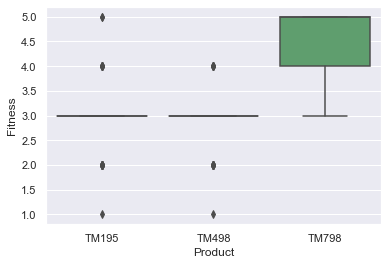

```python
# Let's see how the fitness level varies across products
sns.boxplot(data = cdata, x ='Product', y ='Fitness');
```

To the extent we can infer from the data, it does appear that the median fitness level of TM798 product is higher than those of the other two products.

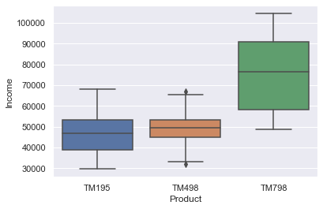

```python
# Since we have the customer income data available, let's see how it varies across products.
sns.boxplot(data = cdata, x ='Product', y ='Income');
```

The median income of TM798 product is significantly higher than those of the other two products. It appears that the TM798 product is assoiated with more educated, affluent, more fit customers who use the product more. We can make no claim on whether this product leads to higher fitness or, more fit people tend to buy this product. All we know is there is a correlation.

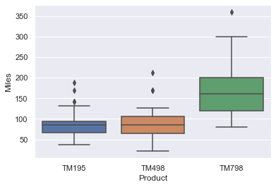

```python
# Since we have the miles data, we can also see how it varies across products.
# Intuitively, miles should be strongly correlated with usage and it should have a similar distribution as usage.
# In fact, the heatmap report shows that there's a strong correlation between usage and miles.

sns.boxplot(data = cdata, x ='Product', y ='Miles');
```

Indeed. As expected, miles distribution is similar to that of usage. This plot above doesn't really provide a lot of new information.

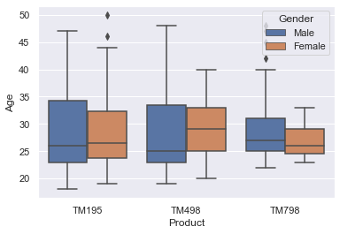

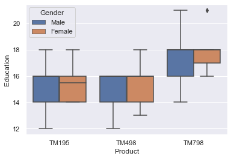

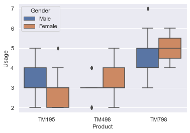

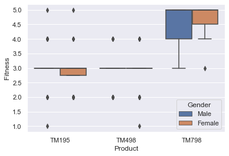

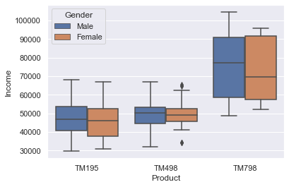

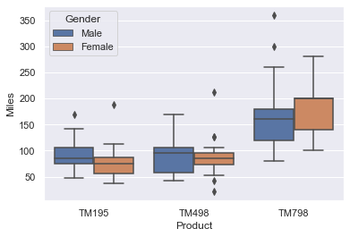

```python
# Let's repeat the plots but with an additional gender dimension. The goal is to see if there's any significant difference in product/customer profile by gender.
# The plots are plotted in a single column, rather than a grid, so it's easier to view on a mobile device.

sns.boxplot(data = cdata, x ='Product', y ='Age', hue='Gender');
plt.show()
sns.boxplot(data = cdata, x ='Product', y ='Education', hue='Gender');
plt.show()
sns.boxplot(data = cdata, x ='Product', y ='Usage', hue='Gender');
plt.show()
sns.boxplot(data = cdata, x ='Product', y ='Fitness', hue='Gender');
plt.show()
sns.boxplot(data = cdata, x ='Product', y ='Income', hue='Gender');
plt.show()
sns.boxplot(data = cdata, x ='Product', y ='Miles', hue='Gender');
plt.show()
```

1. Unlike the other products, for TM798, the medial age for male customers is slightly higher than female customers.
2. The median income of male customers for TN798 is higher than those of female customers. This could just due to higher age or there could be another reason.
3. For everything else, the breakdown by gender does not seem to give us any additional insights.

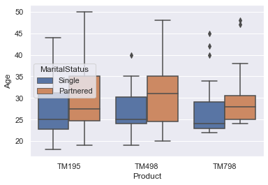

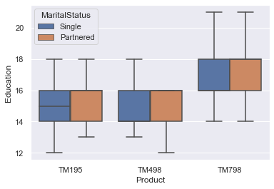

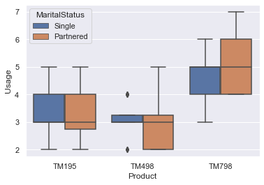

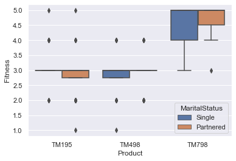

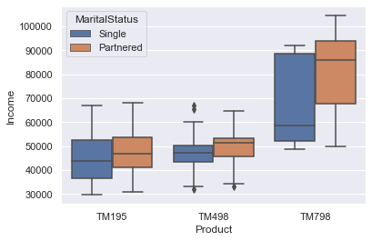

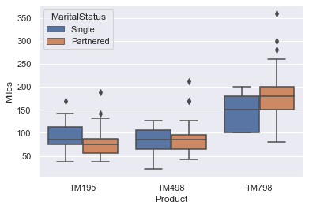

```python
# Let's repeat the analysis but instead of gender, let's use marital status as the second dimension

sns.boxplot(data = cdata, x ='Product', y ='Age', hue='MaritalStatus');
plt.show()
sns.boxplot(data = cdata, x ='Product', y ='Education', hue='MaritalStatus');
plt.show()
sns.boxplot(data = cdata, x ='Product', y ='Usage', hue='MaritalStatus');
plt.show()
sns.boxplot(data = cdata, x ='Product', y ='Fitness', hue='MaritalStatus');
plt.show()
sns.boxplot(data = cdata, x ='Product', y ='Income', hue='MaritalStatus');
plt.show()
sns.boxplot(data = cdata, x ='Product', y ='Miles', hue='MaritalStatus');
plt.show()
```

1. Partnered people tend to be older and have a higher income. This seems consistent with general intuition.
2. For TM798 product, partnered customers have a higher miles. For the other products, it's almost the same across marital status.

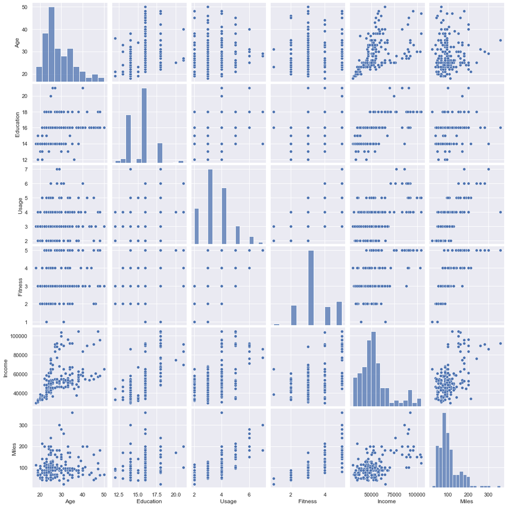

```python
# Let's do a pair plot to see if there are additional insights.
# The scatter plot are examples of multivariate plots, whereas, the plots on the diagonal cells of the matrix are univariate plots.
sns.pairplot(cdata);
```

```python
# Let's also print the correlation numbers.
cdata.corr()
```

|  | Age | Education | Usage | Fitness | Income | Miles |
| --- | --- | --- | --- | --- | --- | --- |
| Age | 1.000000 | 0.280496 | 0.015064 | 0.061105 | 0.513414 | 0.036618 |
| Education | 0.280496 | 1.000000 | 0.395155 | 0.410581 | 0.625827 | 0.307284 |
| Usage | 0.015064 | 0.395155 | 1.000000 | 0.668606 | 0.519537 | 0.759130 |
| Fitness | 0.061105 | 0.410581 | 0.668606 | 1.000000 | 0.535005 | 0.785702 |
| Income | 0.513414 | 0.625827 | 0.519537 | 0.535005 | 1.000000 | 0.543473 |
| Miles | 0.036618 | 0.307284 | 0.759130 | 0.785702 | 0.543473 | 1.000000 |

1. Age and Income are (weakly) positively correlated (this was also observed in the correlation heatmap)
2. Income is (weakly) positively correlated with miles.
3. Education and income are positively correlated.
4. Miles and fitness are strongly correlated as expected.
5. Usage and miles are strongly correlated as expected.

# Customer profile

1. The TM798 product is more prevalent among wealthier, more educated people who use the product more.
2. It also appears that this product appeals to customers in a narrow band of age (25 to 30 years old).
3. There seems to be no significant differences between the customer profiles of the other two products.

# Insights and recommendations

1. The TM798 product sells the fewest in number. Clearly, this is not a high volume product. A high profit margin on this product will be a good idea. (Read below)
2. The TM798 product is associated with wealthier, more educated people who are getting more value from this product.
3. This customer segment can be expected to be willing to and capable of paying a higher price. A price increase can be tested for this product.
4. The 25-30 age bracket is a significantly large portion of the customer base. An upsell promotion campaign could be launched to switch customers to the (now higher priced) TM798 product, leading to a higher revenue and profit.
5. Since there is not a significant difference in the customer profile of the other two products, it could make sense to discontinue the one that has a lower profit margin. This could lead to savings in maintenance, sales training and spare part costs. Of course, this decision has to be made keeping in mind other factors that may prevent such a discontinuance.